{% raw %}

{% endraw %} {% raw %}

{% endraw %} {% raw %}

```python
data = Path.cwd()/'sample_data/Patches_MGI_256_5'
```

{% endraw %} {% raw %}

`class` `TensorDataset`[[source]](https://github.com/schwobr/grade_classif/tree/master/grade_classif/data/dataset.py#L22)

> `TensorDataset`(**`ds`**:`Dataset`, **`tfms`**:`Optional`[`Sequence`[`BasicTransform`]]=*`None`*, **`tfm_y`**:`bool`=*`True`*) :: `Dataset`

{% endraw %} {% raw %}

{% endraw %}

Wrapper around a dataset that generates tensors from the outputs of the dataset's `__getitem__` method using `np_to_tensor`. Can also apply transforms using [albumentations](https://albumentations.readthedocs.io/en/latest/). Pass `tfm_y=False` if you don't want to apply transforms to `y` (when doing classification for instance). Loaders should be instances of `ImageLoader`, `MaskLoader` or `CategoryLoader` for it to work correctly.

{% raw %}

`class` `SplitDataset`[[source]](https://github.com/schwobr/grade_classif/tree/master/grade_classif/data/dataset.py#L72)

> `SplitDataset`(**`train`**:`Dataset`, **`valid`**:`Dataset`, **`test`**:`Dataset`=*`None`*)

SplitDataset(train: torch.utils.data.dataset.Dataset, valid: torch.utils.data.dataset.Dataset, test: torch.utils.data.dataset.Dataset = None)

{% endraw %} {% raw %}

{% endraw %}

Wrapper that contains a `train`, a `valid` and optionally a `test` datasets.

{% raw %}

`SplitDataset.to_tensor`[[source]](https://github.com/schwobr/grade_classif/tree/master/grade_classif/data/dataset.py#L79)

> `SplitDataset.to_tensor`(**`tfms`**:`Optional`[`Sequence`[`BasicTransform`]]=*`None`*, **`tfm_y`**:`bool`=*`True`*, **`test_tfms`**:`Optional`[`Sequence`[`BasicTransform`]]=*`None`*)

Transforms all datasets into `TensorDataset` objects

{% endraw %} {% raw %}

`class` `MyDataset`[[source]](https://github.com/schwobr/grade_classif/tree/master/grade_classif/data/dataset.py#L96)

> `MyDataset`(**`items`**:`Sequence`[`Any`], **`labels`**:`Sequence`[`Any`], **`item_loader`**:`ItemLoader`, **`label_loader`**:`ItemLoader`) :: `Dataset`

{% endraw %} {% raw %}

{% endraw %}

Base class for all datasets. It is constructed using list of `items` and `labels`, most of the time as `Path` or `str` objects, with corresponding `item_loader` and `label_loader` as `ItemLoader` objects.

{% raw %}

`MyDataset.from_folder`[[source]](https://github.com/schwobr/grade_classif/tree/master/grade_classif/data/dataset.py#L121)

> `MyDataset.from_folder`(**`folder`**:`Path`, **`label_func`**:`Callable`[`Path`, `Any`], **`item_loader`**:`ItemLoader`, **`label_loader`**:`ItemLoader`, **`recurse`**:`bool`=*`True`*, **`extensions`**:`Optional`[`Sequence`[`str`]]=*`None`*, **`include`**:`Optional`[`Sequence`[`str`]]=*`None`*, **`exclude`**:`Optional`[`Sequence`[`str`]]=*`None`*, **`filterfunc`**:`Optional`[`Callable`[`Path`, `bool`]]=*`None`*)

Creates a `MyDataset` object by reading files from a folder. It uses `get_item` and therefore works the same.

{% endraw %} {% raw %}

```python
ds = MyDataset.from_folder(data, lambda x: x.parts[-3], ImageLoader(), CategoryLoader(classes=['1', '3']))
ds.items[::20], ds.labels[::20]
```

```
(array([PosixPath('/home/DeepLearning/grade_classif/nbs/sample_data/Patches_MGI_256_5/1/CF_PACS04rescan_07P0201/CF_PACS04rescan_07P0201_40960_131072.png'),
        PosixPath('/home/DeepLearning/grade_classif/nbs/sample_data/Patches_MGI_256_5/1/CF_PACS04rescan_07P0201/CF_PACS04rescan_07P0201_40960_81920.png'),
        PosixPath('/home/DeepLearning/grade_classif/nbs/sample_data/Patches_MGI_256_5/1/CF_PACS05HE_03026-04H2669/CF_PACS05HE_03026-04H2669_57344_155648.png'),
        ...,
        PosixPath('/home/DeepLearning/grade_classif/nbs/sample_data/Patches_MGI_256_5/3/CF_PACS05HE_06003-172.608I/CF_PACS05HE_06003-172.608I_0_163840.png'),
        PosixPath('/home/DeepLearning/grade_classif/nbs/sample_data/Patches_MGI_256_5/3/CF_PACS05HE_06003-172.608I/CF_PACS05HE_06003-172.608I_40960_114688.png'),
        PosixPath('/home/DeepLearning/grade_classif/nbs/sample_data/Patches_MGI_256_5/3/CF_PACS05HE_06003-172.608I/CF_PACS05HE_06003-172.608I_32768_139264.png')],
       dtype=object), array(['1', '1', '1', ..., '3', '3', '3'], dtype='<U1'))
```

{% endraw %} {% raw %}

`MyDataset.to_tensor`[[source]](https://github.com/schwobr/grade_classif/tree/master/grade_classif/data/dataset.py#L149)

> `MyDataset.to_tensor`(**`tfms`**:`Optional`[`Sequence`[`BasicTransform`]]=*`None`*, **`tfm_y`**:`bool`=*`True`*)

Creates a `TensorDataset` based on this dataset.

{% endraw %} {% raw %}

`MyDataset.split_by_list`[[source]](https://github.com/schwobr/grade_classif/tree/master/grade_classif/data/dataset.py#L157)

> `MyDataset.split_by_list`(**`train`**:`Tuple`[`Sequence`[`Any`], `Sequence`[`Any`]], **`valid`**:`Tuple`[`Sequence`[`Any`], `Sequence`[`Any`]], **`test`**:`Optional`[`Tuple`[`Sequence`[`Any`], `Sequence`[`Any`]]]=*`None`*)

Creates a `SplitDataset` using `train`, `valid` and optionally `test` tuples. Each tuple contains 2 lists: one for items and one for labels.

{% endraw %} {% raw %}

`MyDataset.split_by_folder`[[source]](https://github.com/schwobr/grade_classif/tree/master/grade_classif/data/dataset.py#L174)

> `MyDataset.split_by_folder`()

Creates a `SplitDataset` by looking for `ŧrain`, `valid` and `test` in item paths and splitting the dataset accordingly.

{% endraw %} {% raw %}

`MyDataset.split_by_csv`[[source]](https://github.com/schwobr/grade_classif/tree/master/grade_classif/data/dataset.py#L195)

> `MyDataset.split_by_csv`(**`csv`**:`Union`[`Path`, `str`], **`split_column`**:`str`=*`'split'`*, **`id_column`**:`str`=*`'scan'`*, **`get_id`**:`Optional`[`Callable`[`Any`, `Any`]]=*`None`*)

Creates a `SplitDataset` by using a csv that contains an `id_column` column for identifying items and a `split_column` column that contains either `'train'`, `'valid'` or `'test'`. `get_id` is the function used to extract the item's id from the item itself. By default it considers that `item` is a `Path` object and takes the parent folder's name as id.

{% endraw %} {% raw %}

`class` `ClassDataset`[[source]](https://github.com/schwobr/grade_classif/tree/master/grade_classif/data/dataset.py#L232)

> `ClassDataset`(*`args`, **`n_classes`**:`int`=*`2`*, **`kwargs`) :: `MyDataset`

{% endraw %} {% raw %}

{% endraw %}

`MyDataset` subclass for classification. Stores an additionnal `n_classes` attribute.

{% raw %}

`class` `ImageClassifDataset`[[source]](https://github.com/schwobr/grade_classif/tree/master/grade_classif/data/dataset.py#L238)

> `ImageClassifDataset`(*`args`, **`n_classes`**:`int`=*`2`*, **`kwargs`) :: `ClassDataset`

{% endraw %} {% raw %}

{% endraw %} {% raw %}

```python
from grade_classif.params.parser import hparams
hparams.filt = 'all'
if hparams.concepts is not None and hparams.concept_classes is not None:
    conc_classes_df = pd.read_csv(hparams.concept_classes, index_col=0)
    if hparams.filt != 'all':
        ok = conc_classes_df.loc[conc_classes_df['type'] == hparams.filt].index.values
    else:
        ok = conc_classes_df.loc[conc_classes_df['type'] != 'garb'].index.values
    conc_df = pd.read_csv(hparams.concepts, index_col='patchId')
    def filt(x):
        return conc_df.loc[x.stem, 'concept'] in ok
else:
    filt = None
hparams.data = Path('/data/DeepLearning/SCHWOB_Robin/Patches_256/Patches_256_1')
data = (ImageClassifDataset.
        from_folder(Path(hparams.data), lambda x: x.parts[-3], classes=['1', '3'], extensions=['.png'], include=['1', '3'], filterfunc=filt).
        split_by_csv(hparams.data_csv))
```

{% endraw %} {% raw %}

```python
(data.train.labels == '3').sum()
```

```
216558
```

{% endraw %} {% raw %}

`ImageClassifDataset.from_folder`[[source]](https://github.com/schwobr/grade_classif/tree/master/grade_classif/data/dataset.py#L277)

> `ImageClassifDataset.from_folder`(**`folder`**:`Union`[`str`, `Path`], **`label_func`**:`Callable`[`Path`, `Any`], **`n_classes`**:`Optional`[`int`]=*`None`*, **`classes`**:`Optional`[`Sequence`[`Any`]]=*`None`*, **`recurse`**:`bool`=*`True`*, **`extensions`**:`Optional`[`Sequence`[`str`]]=*`None`*, **`include`**:`Optional`[`Sequence`[`str`]]=*`None`*, **`exclude`**:`Optional`[`Sequence`[`str`]]=*`None`*, **`filterfunc`**:`Optional`[`Callable`[`Path`, `bool`]]=*`None`*, **`kwargs`)

Overwrites `MyDataset.from_folder`. Works basically the same but you don't need to pass loaders, but instead `n_classes` or `classes` arguments. Loaders are automatically created using these.

{% endraw %}

`ClassDataset` subclass for image classification.

{% raw %}

```python
ds = ImageClassifDataset.from_folder(data, lambda x: x.parts[-3], classes=['1', '3'])
```

{% endraw %} {% raw %}

`ImageClassifDataset.show`[[source]](https://github.com/schwobr/grade_classif/tree/master/grade_classif/data/dataset.py#L239)

> `ImageClassifDataset.show`(**`k`**:`int`, **`ax`**:`Axes`=*`None`*, **`figsize`**:`Tuple`[`int`, `int`]=*`(3, 3)`*, **`hide_axis`**:`bool`=*`True`*, **`cmap`**:`str`=*`'viridis'`*, **`kwargs`)

Shows the `k`th image from the dataset with the corresponding label.

{% endraw %} {% raw %}

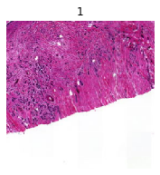

```python
ds.show(0)
```

{% endraw %} {% raw %}

`ImageClassifDataset.show_rand`[[source]](https://github.com/schwobr/grade_classif/tree/master/grade_classif/data/dataset.py#L263)

> `ImageClassifDataset.show_rand`(**`ax`**:`Axes`=*`None`*, **`figsize`**:`Tuple`[`int`, `int`]=*`(3, 3)`*, **`hide_axis`**:`bool`=*`True`*, **`cmap`**:`str`=*`'viridis'`*, **`kwargs`)

Shows a random image from the dataset with the corresponding label.

{% endraw %} {% raw %}

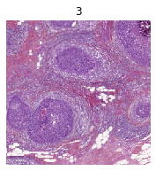

```python
ds.show_rand()
```

{% endraw %} {% raw %}

`class` `ImageSegmentDataset`[[source]](https://github.com/schwobr/grade_classif/tree/master/grade_classif/data/dataset.py#L314)

> `ImageSegmentDataset`(*`args`, **`n_classes`**:`int`=*`2`*, **`kwargs`) :: `ClassDataset`

{% endraw %} {% raw %}

{% endraw %}

`ClassDataset` subclass for image segmentation.

{% raw %}

`ImageSegmentDataset.from_folder`[[source]](https://github.com/schwobr/grade_classif/tree/master/grade_classif/data/dataset.py#L359)

> `ImageSegmentDataset.from_folder`(**`folder`**:`Union`[`Path`, `str`], **`label_func`**:`Callable`[`Path`, `Path`], **`n_classes`**:`Optional`[`int`]=*`None`*, **`classes`**:`Optional`[`Any`]=*`None`*, **`recurse`**:`bool`=*`True`*, **`extensions`**:`Optional`[`Sequence`[`str`]]=*`None`*, **`include`**:`Optional`[`Sequence`[`str`]]=*`None`*, **`exclude`**:`Optional`[`Sequence`[`str`]]=*`None`*, **`filterfunc`**:`Optional`[`Callable`[`Path`, `bool`]]=*`None`*)

Same as `ImageClassifDataset.from_folder`.

{% endraw %} {% raw %}

`ImageSegmentDataset.show`[[source]](https://github.com/schwobr/grade_classif/tree/master/grade_classif/data/dataset.py#L315)

> `ImageSegmentDataset.show`(**`k`**:`int`, **`ax`**:`Axes`=*`None`*, **`figsize`**:`Tuple`[`int`, `int`]=*`(3, 3)`*, **`title`**:`Optional`[`str`]=*`None`*, **`hide_axis`**:`bool`=*`True`*, **`cmap`**:`str`=*`'tab20'`*, **`kwargs`)

Shows the `k`th image from the dataset with the corresponding mask above it.

{% endraw %} {% raw %}

`ImageSegmentDataset.show_rand`[[source]](https://github.com/schwobr/grade_classif/tree/master/grade_classif/data/dataset.py#L345)

> `ImageSegmentDataset.show_rand`(**`ax`**:`Axes`=*`None`*, **`figsize`**:`Tuple`[`int`, `int`]=*`(3, 3)`*, **`hide_axis`**:`bool`=*`True`*, **`cmap`**:`str`=*`'tab20'`*, **`kwargs`)

Shows a random image from the dataset withthe corresponding mask above it.

{% endraw %} {% raw %}

`class` `NormDataset`[[source]](https://github.com/schwobr/grade_classif/tree/master/grade_classif/data/dataset.py#L394)

> `NormDataset`(**`items`**:`Sequence`[`Any`], **`labels`**:`Sequence`[`Any`], **`item_loader`**:`ItemLoader`, **`label_loader`**:`ItemLoader`) :: `MyDataset`

{% endraw %} {% raw %}

{% endraw %} {% raw %}

`NormDataset.from_folder`[[source]](https://github.com/schwobr/grade_classif/tree/master/grade_classif/data/dataset.py#L431)

> `NormDataset.from_folder`(**`folder`**:`Union`[`Path`, `str`], **`recurse`**:`bool`=*`True`*, **`extensions`**:`Optional`[`Sequence`[`str`]]=*`None`*, **`include`**:`Optional`[`Sequence`[`str`]]=*`None`*, **`exclude`**:`Optional`[`Sequence`[`str`]]=*`None`*, **`filterfunc`**:`Optional`[`Callable`[`Path`, `bool`]]=*`None`*, **`kwargs`)

Overwrites `MyDataset.from_folder` so that it doesn't need the loaders or a `label_func`.

{% endraw %}

`MyDataset` subclass to use for a grayscale to color unet.

{% raw %}

```python
ds = NormDataset.from_folder(data)
```

{% endraw %} {% raw %}

`NormDataset.show`[[source]](https://github.com/schwobr/grade_classif/tree/master/grade_classif/data/dataset.py#L395)

> `NormDataset.show`(**`k`**:`int`, **`axs`**:`Axes`=*`None`*, **`figsize`**:`Tuple`[`int`, `int`]=*`(5, 5)`*, **`title`**:`Optional`[`str`]=*`None`*, **`hide_axis`**:`bool`=*`True`*, **`cmap`**:`str`=*`'viridis'`*, **`kwargs`)

Shows the `k`th image from the dataset as grayscale and colored.

{% endraw %} {% raw %}

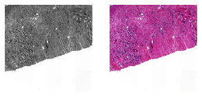

```python
ds.show(0)
```

{% endraw %} {% raw %}

`NormDataset.show_rand`[[source]](https://github.com/schwobr/grade_classif/tree/master/grade_classif/data/dataset.py#L417)

> `NormDataset.show_rand`(**`axs`**:`Axes`=*`None`*, **`figsize`**:`Tuple`[`int`, `int`]=*`(5, 5)`*, **`hide_axis`**:`bool`=*`True`*, **`cmap`**:`str`=*`'viridis'`*, **`kwargs`)

Shows a random image from the dataset as grayscale and colored.

{% endraw %} {% raw %}

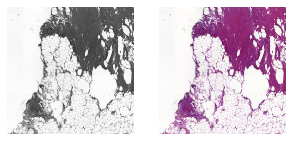

```python
ds.show_rand()
```

{% endraw %}